# Continuous Random Variables

Fei Ye

March 2026

## 1 Learning Goals

- Demonstrate understanding of characteristics of normal distributions.
- Calculate accurate probabilities of continuous random variables and interpret them in a variety of settings.
- Calculate the standardized value (or \(z\)-score).

## 2 Distribution of a Continuous Random Variable

The probability distribution of a continuous random variable \(X\) is characterized by its **probability density function** \(f(X)\) satisfying that the probability \(P(a\leq X\leq b)\) equals the area above the interval \([a, b]\) but under the graph of the density function \(f(X)\) which is also called a **density curve**.

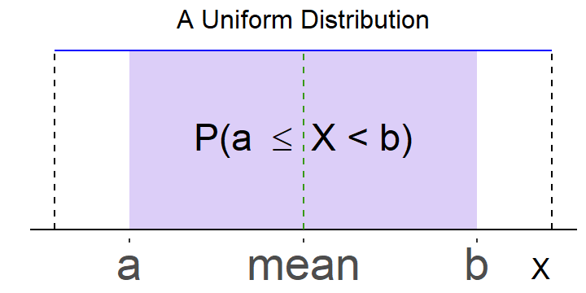

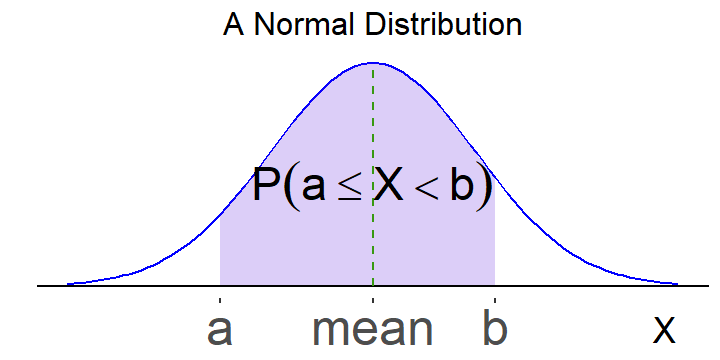

## 3 Properties of Distribution of a Continuous Variable

- The probability density function \(f\) is nonnegative, that is \(f(X)\ge 0\).
- The total area under a density curve is 1.
- The cumulative probability \(P(X\le b)\) of a random variable \(X\) equals the area under the density curve to the left side of \(b\).
- By the addition rule of probability, we have
  - $$P(a\le X\le b)=P(X\le b)-P(X\le a)$$
  - $$P(X\ge b)=1-P(X\le b)$$
- As a line segment has no area, we have \(P(X\le a)=P(X< a)\) as well as \(P(X\ge b)=P(X>b)\)

## 4 Example: An Uniform Distribution

Let \(X\) be the amount of time that a commuter must wait for a train. Suppose \(X\) has a probability density function $$ f(X)= \begin{cases} 0.1, & 0\leq X\leq 10\\ 0, & \text{otherwise} \end{cases} $$

What is the probability that the commuter’s waiting time is less than 4 minutes?

**Solution:** The probability \(P(X\leq 4)\) is the area under the horizontal line \(y=0.1\) to the left of \(X=4\).

Since \(f(X)=0\) for \(X<0\), the area is the area of the rectangle with width 4 and height 0.1. So the probability is \(P(X\leq 4)=0.1\cdot 4=0.4\).

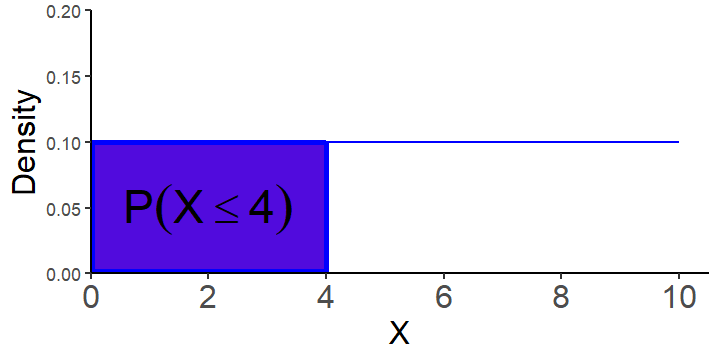

## 5 Normal Distribution

- A **normal distribution** has a **density function** \(f(x)=\frac{1}{\sqrt{2\pi \sigma^2}}e^{-\frac{(x-\mu)^2}{2\sigma^2}},\) where \(\mu\) is the mean, \(\sigma\) is the standard deviation, \(\pi\approx 3.14159\) and \(e\approx 2.71828\). The graph of \(f\) is called a **normal curve**.
- We write \(X\sim N(\mu, \sigma^2)\) for a normal random variable \(X\) with the mean \(\mu\) and the standard deviation \(\sigma\).
- A normal distribution has the following properties:
  - *The mean, median, and mode are equal*.
  - The normal curve is *bell shaped and **symmetric*** with respect to the mean.
  - The *total area* under the curve and above the \(x\)-axis is \(1\).
  - The normal curve *approaches, but never touches, the \(x\)-axis* as \(x\) goes to \(\pm\infty\).

## 6 Normal Curves with Different Means and Standard Deviations

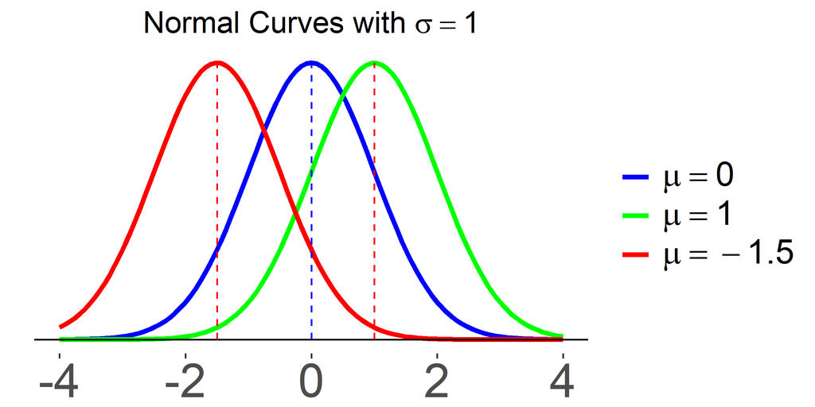

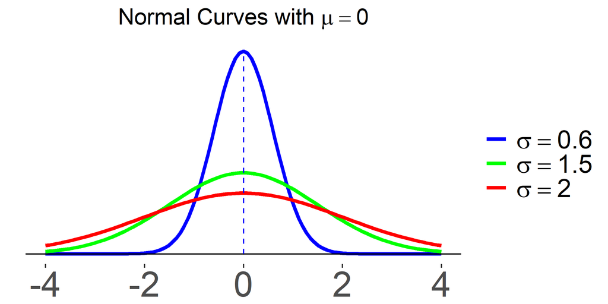

## 7 The Empirical Rule for Normal Distributions

For any normal distribution, the proportion of data values within 1, 2, and 3 standard deviations away from the mean are approximately 68.3%, 95.4% and 99.7% respectively.

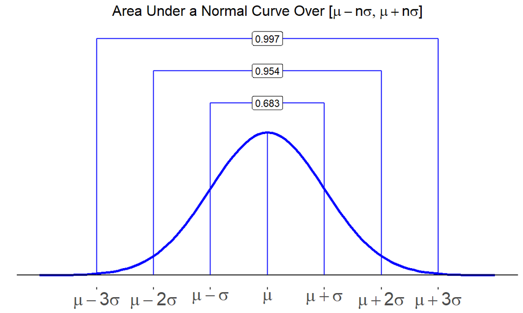

## 8 Example: Foot length (1 of 3)

Suppose that foot length of a randomly chosen adult male is a normal random variable with the mean \(\mu=11\) and the standard deviation \(\sigma=1.5\).

- How likely is a male’s foot length to be smaller than 9.5 inches
- How likely is a male’s foot length to be bigger than 8 inches

**Solution:** Let’s first sketch the normal curve.

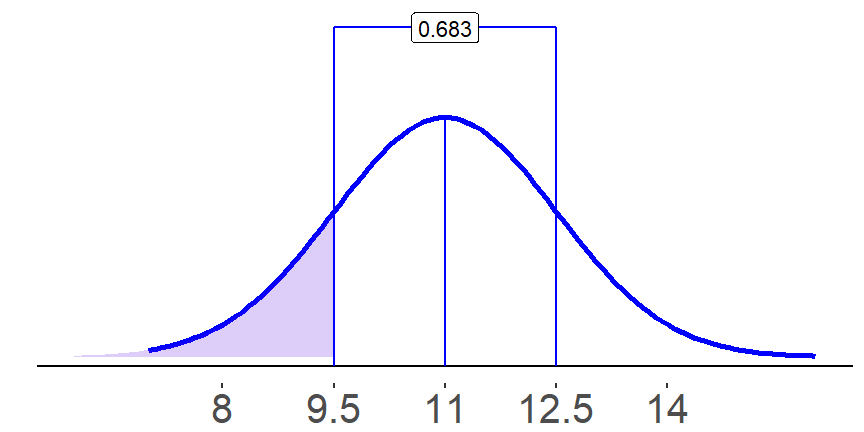

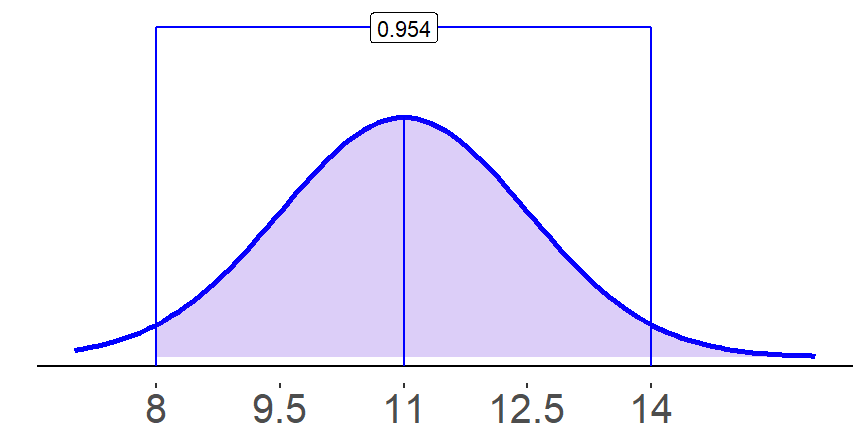

## 9 Example: Foot length (2 of 3)

**Method 1: Using the Empirical Rule**

Note that \(9.5 = 11 - 1.5 = \mu - \sigma\). By the symmetry of normal curve, we know that the probability \(P(X<9.5)\) is the shaded area on the left. Because the probability of getting a foot length within 1 standard deviation away from the mean is 0.683. Then $$P(X<9.5)=\frac12(1-P(9.5<X<12.5))\approx\frac12(1-0.683)=0.1585.$$ Note that \(8=11-2\cdot 1.5=\mu-2\sigma\). Because the probability of getting a foot length within 2 standard deviation away from the mean is 0.954. Then $$P(X>8)=(1-P(X<8))=1-\frac12(1- P(8<X<14))=1-\frac12(1-0.954)=0.977.$$

## 10 Example: Foot length (3 of 3)

**Method 2: Using Excel**

The probability \(P(X<x)\) for a normal random variable \(X\) can be calculated using the Excel function `NORM.DIST(x, mean, sd, TRUE)`.

In this case, \(P(X<9.5)=\) `=NORM.DIST(9.5, 11, 1.5, TRUE)` \(\approx 0.1587.\)

Since \(P(X>8) = 1 - P(X < 8)\) and \(P(X < 8)=\) `NORM.DIST(8, 11, 1.5, TRUE)`, it follows that $$P(X>8) \approx 1 - 0.02275 = 0.97725.$$

## 11 Standard Normal Distribution

- A normal distribution is called a **standard normal distribution** if the mean is \(\mu=0\) and the standard deviation is \(\sigma=1\).
- A random normal variable can be **standardized** by the following formula \(z=\frac{x-\mu}{\sigma}.\) We call the value \(z\) the \(Z\)-**score** of \(x\). In Excel, the \(Z\)-score of \(x\) can be calculated using the function `STANDARDIZE()`.
- Standardization preserves probability: $$\textstyle P(a<X<b)=P\left(\frac{a-\mu}{\sigma}< Z < \frac{b-\mu}{\sigma}\right).$$
- The probability \(P(Z< z)\) of a standard normal random variable \(Z\) can be found using the Excel function `NORM.S.DIST(z, TRUE)` or the standard normal distribution table.
- Recall that the probability \(P(X< x)\) of a normal random variable \(X\) can be calculated using the Excel function `NORM.DIST(x, mean, sd, TRUE)`.

## 12 Example: Standardization Revisited

Let \(X\) be a normal random variable with the mean \(\mu = 8\) and the standard deviation \(\sigma=2\).

1. Find the \(Z\)-score for the value \(X=13\).
2. Find the \(X\)-value for the \(Z\)-score \(z=-0.6\).

**Solution:** The \(z\)-score for the value \(X=13\) is $$z=\dfrac{x-\mu}{\sigma}=\dfrac{13-8}{2}=\dfrac{5}{2}=2.5.$$

The \(X\)-value for the the \(Z\)-score \(z=-0.6\) is $$x=z\cdot\sigma+\mu=-0.6\cdot 2+8=-1.2+8=6.8.$$

## 13 Example: Probabilities of Standard Normal Variables

Let \(Z\) be a standard normal random variable.

1. Find \(P(Z<1.21)\).
2. Find \(P(Z\geq 1.21)\).
3. Find \(P(0<Z\leq 1.21)\).

**Solution:** To find the probability of getting a value less than \(z\), we may use the Excel function `NORM.S.DIST(z,TRUE)`.

1. In this case, \(P(Z<1.21)\) `=NORM.S.DIST(1.21, TRUE)` \(\approx 0.8869\).
2. Since the total area under the normal curve is 1, $$P(Z\geq 1.21) = 1 - P(Z < 1.21) \approx 1-0.8869=0.1131.$$
3. By the symmetry, \(P(Z<0)=0.5\) and $$P(0<Z<1.21) = P(Z < 1.21) - P(Z < 0) \approx 0.8869-0.5=0.3869.$$

## 14 Example: Heights of 25-year-old women

The heights of 25-year-old women in a certain region are approximately normally distributed with mean 62 inches and standard deviation 4 inches. Find the probability that a randomly selected 25-year-old woman is more than 67 inches tall.

**Solution:** Let \(X\) be the height of a randomly selected 25-year-old. From the question, \(X\) is approximately normally distributed with mean 62 inches and standard deviation 4 inches. Since \(P(X>67)=1-P(X\leq 67)\), to find \(P(X>67)\), we find \(P(X\leq 67)\) first.

**Method 1: Using `NORM.DIST(x, mean, SD, TRUE)`**

\(P(X\le 67)\) `NORM.DIST(67, 62, 4, TRUE)` \(\approx 0.8944\).

**Method 2: Using `NORM.S.DIST(z, TRUE)`**

The \(Z\)-score is \(z=\frac{67-62}{4}=1.25\) and \(P(X\le 67)=P(Z<1.25)=\) `NORM.S.DIST(1.25,TRUE)` \(\approx 0.8944\).

Therefore, \(P(X>67) \approx 1-0.8944=0.1056.\)

## 15 Cutoff Value for a Given Tail Area

- The \(k\)-th percentile for a random variable \(X\) is the value \(x_k\) that cuts off a left tail with the area \(k/100\), that is \(P(X<x_k)=\frac{k}{100}\), where \(0\leq k\leq 100\).
- Let \(c\) be a nonnegative number less than 0.5. The \((100c)\)-th percentile for the standard normal distribution is usually denoted as \(-z_c\), that is \(P(Z<-z_c)=c<0.5\). By symmetry, \(z_c\) is the value such that \(P(Z> z_c)=c\), that is \(P(Z<z_c)=1-c\).
  - **Note:** the cutoff value \(z_c\) is positive if \(c<0.5\).
  - In Excel, if \(c<0.5\), the cutoff value \(z_c\) such that \(P(Z > z_c)=c\) can be calculated using the function `NORM.S.INV(1-c)`.
- For a normal random variable \(X\) with the mean \(\mu\) and standard deviation \(\sigma\), the cutoff value \(x^*\) with a **tail area** \(p\), can be calculated using the Excel function `NORM.INV(p, mean, sd)`, or the standardization formula, that is, \(x^*=z^*\cdot \sigma+\mu,\) where \(z^*\) is the cutoff \(z\)-score with the tail area \(p\), that is \(z^*=\) `NORM.S.INV(p)`.

## 16 Example: Cutoff Value

Let \(X\) be the normal random variable with mean \(6\) and standard deviation \(3\). Suppose the value \(x^*\) cuts off a left-tail area \(0.05\). Find the value \(x^*\).

**Solution:** Since the \(x^*\) cuts off a left-tail, to find the value \(x^*\):

**Method 1:** \(x^*=\) `NORM.INV(0.05, 6, 3)` \(\approx 1.065.\)

**Method 2:** Let \(z^*\) be the cutoff \(z\)-score with the tail area \(0.05\). Then \(z^*=\) `NORM.S.INV(0.05)` \(\approx -1.645.\) Then $$x^*=z^*\cdot \sigma+\mu=-1.645\cdot 3+6=1.065.$$

## 17 Example: Math Course Placement

Scores on a standardized college placement examination are normally distributed with mean 60 and standard deviation 13. Students whose scores are in the top \(5\%\) will be placed in a Calculus II course. Find the minimum score needed to be placed in a Calculus II course.

**Solution:** Let \(x^*\) be the minimum score. From the question, we know that \(P(X\geq x^*)=5\%\). Equivalently, \(P(X<x^*)=1 - 5\%\).

**Method 1:** \(x^*=\) `NORM.INV(1-5%, 60, 13)` \(\approx 81.38.\)

**Method 2:** Let \(z^*\) be the cutoff \(z\)-score with the tail area \(1-5%\). Then \(z^*=\) `NORM.S.INV(1-5%)` \(\approx 1.64.\) Then $$x^*=z^*\cdot \sigma+\mu=1.64\cdot 13+60=81.32.$$

So the minimum score needed to be placed in a Calculus II course is \(82\).

**Note:** The minimum score is the same as the 95th percentile.

## Practice: Dash washing time

[interactive chart not shown]

## Practice: Fruit weight

[interactive chart not shown]

## Practice: Shortest lifespan

[interactive chart not shown]

## Practice: Battery life

[interactive chart not shown]

## Practice: Sum of Normal Random Variables

Let \(Z\) be a normal random variable with \(\mu=0\) and \(\sigma=1\). Let \(X\) be a normal random variable with \(\mu=4.3\) and \(\sigma=1.7\).

Determine the values \(P(Z>1) + P(X<6)\) and explain how do you find the value.

Extra Practice

## Practice: Area under a normal curve

[interactive chart not shown]

## Practice: Find cutoff \(Z\)-scores

[interactive chart not shown]

## Practice: Chocolate Chips in Acceptable Cookies

[interactive chart not shown]

## Practice: Blood Pressure

[interactive chart not shown]

Lab Instructions in Excel

## 18 Excel Functions for Normal Distributions

- Let \(Z\) be a standard normal random varaible. In Excel, \(P(Z<z)\) is given by `NORM.S.DIST(z, TRUE)`.
- Let \(X\) be a normal random variable with mean \(\mu\) and standard deviation \(\sigma\), that is \(X\sim N(\mu, \sigma^2)\). In Excel, \(P(X<x)\) is given by `NORM.DIST(x, mean, sd, TRUE)`.
- When a cumulative probability \(p=P(X<x)\) of a normal random variable \(X\) is given, we can find \(x\) using `NORM.INV(p, mean, sd)`.
- When a cumulative probability \(p=P(Z<z)\) of a standard normal random variable \(Z\) is given, we can find \(z\) using `NORM.S.INV(p)`.

## 19 Lab Practice: Normal Variable

1. Let \(Z\) be a standard normal random variable. Find the probabilities: $$\text{1.}\,\, P(Z<1.58)\quad \text{2.}\,\, P(-0.6<Z<1.67)\quad \text{3.}\,\, P(Z>0.19).$$
2. Let \(X\) be a normal random variable with \(\mu=5\) and \(\sigma=2\). Find the probabilities: $$\text{1.}\,\, P(-2<X<8)\quad \text{2.}\,\, P(X>-1) \quad \text{3.}\,\, P(X<4).$$